# Gaussian Process Regression

#### Different kernels:

From [Robert Gramacy Surrogates: Gaussian Process Modeling, Design and Optimization for the Applied Sciences 5.3.3. Stationary kernels](https://bookdown.org/rbg/surrogates/chap5.html):

If a Gaussian kernel isn’t working well, or if you want finer control on mean-square differentiability, then consider a Matérn family member, with

$$k_\nu(x,x')=\frac{2^{1-\nu}}{\Gamma(\nu)}\left(\Vert
x - x' \Vert \sqrt{\frac{2\nu}{l}} \right)^\nu K_\nu \left(\Vert x -
x' \Vert \sqrt{\frac{2\nu}{l}}\right)$$

which can be recognized as (a re-parameterized) Gaussian family, where $\Vert x - x'\Vert$ is measured on the scale of ordinary (not squared) Euclidean distances.

The code below sets up this “full” Matérn in R so we can play with it a little.

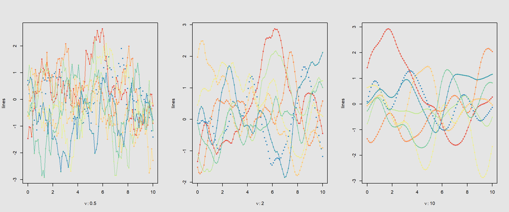

```r
matern <- function(X1, X2, theta=1, nu=1/2) {
  Sigma <- matrix(rep(0, length(X1) * length(X2)), nrow=length(X1))
  for (i in 1:nrow(Sigma)) {
    for (j in 1:ncol(Sigma)) {
      r <- abs(X1[i] - X2[j])
      Sigma[i,j] <- 2^(1 - nu)/gamma(nu) * (r * sqrt(2*nu/theta))^nu * besselK(r * sqrt(2*nu/theta), nu)
    }
  }
  Sigma[is.nan(Sigma)] <- 1
  return(Sigma)
}

# 1. Plot some sample functions from the Gaussian process

# Define the points at which we want to define the functions
x.st <- seq(0, 10, len = 100)

# Generate a number of functions from the process
n.samples <- 8
set.seed(0)
par(mfrow=c(1,3))
par(bg='gray90')
nu <- c(1/2,2,10)
for (j in 1:3){
# Initiate a matrix with ncols = length x.star and 3 cols (no. samples):
fsta <- matrix(rep(0, length(x.st) * n.samples), ncol = n.samples)
for (i in 1:n.samples) {
  # Each column represents a sample from a multivariate normal distribution with zero mean and covariance sigma
  fsta[,i] <- mvrnorm(1, rep(0, length(x.st)), matern(x.st, x.st, theta=1, nu=nu[j]))
}
vl <- cbind(x = x.st, as.data.frame(fsta))
val <- melt(vl, id="x")

co <- brewer.pal(n = n.samples, name = 'Spectral')

plot(val$x, val$value, col=co[val$variable], pch=19, cex=0.5, xlab=call(':', quote(nu), nu[j])
, ylab='lines')

for(l in 2:n.samples) lines(vl$x, vl[,l], col=co[l])
}
```

### FITTING DATASET:

Now let us assume that we have some known data points. In the book, the notation ‘f’ is used for f$y below.

```r
f <- data.frame(x = c(-4,-3,-1,0,2), y = c(-2,0,1,2,-1))
```

The following matrix calculations correspond to equation (2.19) in the book:
$$\begin{align}\large
f_* \mid X_∗ , X, f ∼ {\cal{N}} \left(K(X_∗, X)K(X, X)^{−1} f, \quad
K(X_∗, X_∗) − K(X_∗, X) K(X, X)^{−1} K(X, X_∗) \right)
\end{align}$$

where $X$ are the independent variable of the sample and $X_*$ are values initially employed to build the curves, i.e. not the sample, but just the $x$ axis (both $x$ and $x'$ are considered index variables or the equivalent of independent variables).

This derivation is heavy according to mathematicalmonk. However, this is simply the multivariate Gaussian conditional distribution.

In linear algebra, as explained in [here](https://www.youtube.com/live/GWHE5vnpxks?si=vFF_3CzZbAn7iPaB&t=3909):

The sample or known points in a GP are $X = f(x_1), f(x_2), \dots, f(x_n)$ the unknown points are $X_* =f(x)$ and $X, X_* \sim N(0, \Sigma).$ The sampled points are not necessarily in the points generating the prior curves (i.e. the $x$ axis of the plot), and it can be considered that together with the sampled points we get a vector of data such as

$$\begin{bmatrix}f(x)\\
f(x_*)\end{bmatrix}\sim \mathcal N\left ( 0, \begin{bmatrix} K(X,X)
& K(X,X_*)\\ K(X_*,X) & K(X_*,X_*)\end{bmatrix}\right )$$
The covariance matrix is a block matrix:

$$\begin{align}\Sigma =
\large \left[\begin{array}{ccc|c}
k(x_1,x_1) & \dots & k(x_1, x_n) & k(x_1,x) \\
\vdots & \ddots & \vdots & \vdots \\
k(x_n,x_1) & \dots & k(x_n, x_n) & k(x_n,x) \\
\hline
k(x,x_1) & \dots & k(x, x_n) & k(x,x) \\
\end{array} \right]
= \left[\begin{array}{c|c}
K_{XX} & K_X(x) \\
\hline
K_X(x)^\top & K(x,x)
\end{array} \right]
\end{align}$$

where $X =\{x_1, \dots, x_n\}$, $[K_{XX}]_{ij}=k(x_i,x_j)$ is the Gram kernel matrix, and $[K_X(x)]_j=k(x_j, x).$

The conditional distribution

$f(x) \mid f(x_1), \dots, f(x_n) \sim {\cal N}(\mu(x), \mathbb V(x))$

with

$\mu(x) = K_X(x)^\top K_{XX}^{-1} \bf \quad f$

where ${\bf f} = [f(x_1), \dots, f(x_n)]^\top$ are the $y$ (dependent variable) sample points, and

$K_X(x)^\top= [k(x,x_1), \dots, k(x,x_n)]$

Notice that this is a matrix multiplication with

$$\mu(x)=\small
\begin{bmatrix}\text{points on }x\text{ axis}\\\times\\ \text{sample
points}\end{bmatrix}\;\begin{bmatrix}\text{sample points}\\\times\\
\text{sample points}\end{bmatrix}\;\begin{bmatrix}\text{sample
points}\\\times\\ 1\end{bmatrix} = \begin{bmatrix}\text{points on
}x\text{ axis}\\\times\\ 1\end{bmatrix}$$

therefore yielding a different mean for each marginal in the conditional distribution.

The variance is

$\mathbb V(x) = K(x,x) - K_X(x)^\top K_{XX}^{-1} K_x(x)$

Note that each curve is a single sample of the (theoretically) infinite-dimensional multivariate Gaussian. Now, we are talking about just a handful of these components or elements in the vector - so a part of a single sample. It is the same as conditioning on a bivariate:

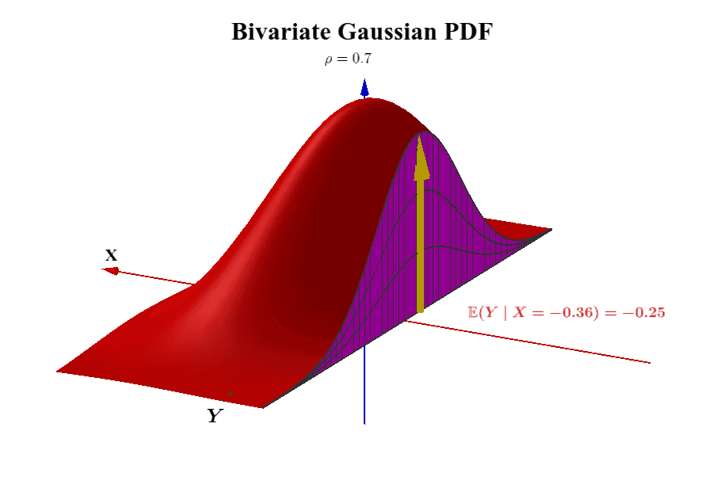

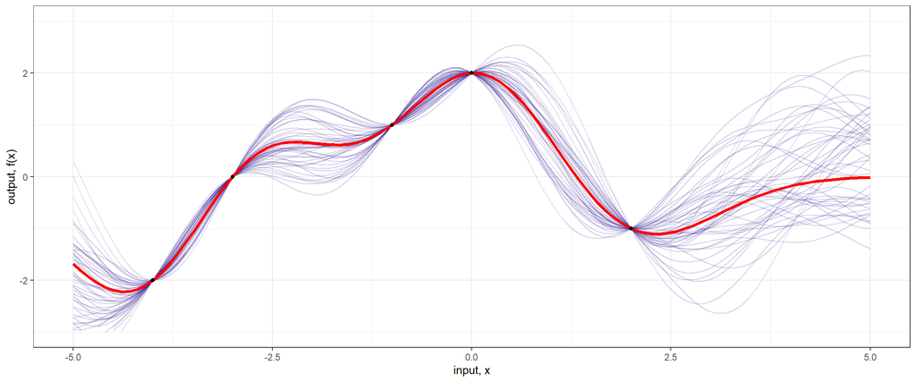

```r
options(warn=-1)
# Calculate the covariance matrices using the same x.star values as above
x      <- f$x
k.xx   <- calcSigma(x,x) # K_{XX}
k.xxs  <- calcSigma(x, x.star) # K_X(x)
k.xsx  <- calcSigma(x.star, x) # K_X(x)^\top
k.xsxs <- calcSigma(x.star, x.star) #K(x,x)


f.star.bar <- k.xsx %*% solve(k.xx) %*% f$y # The mean of the conditional distribution.
cov.f.star <- k.xsxs - k.xsx %*% solve(k.xx) %*% k.xxs

# This time we'll plot more samples.  We could of course simply plot a +/- 2 standard deviation confidence interval
# as in the book but I want to show the samples explicitly here.

n.samples <- 50
values <- matrix(rep(0,length(x.star) * n.samples), ncol=n.samples)

for (i in 1:n.samples) {
  values[,i] <- mvrnorm(1, f.star.bar, cov.f.star)
}
values <- cbind(x=x.star, as.data.frame(values))

values2 <- melt(values, id="x")

# Plot the results including the mean function
# and constraining data points
fig2b <- ggplot(values2, aes(x=x, y=value)) +
  geom_line(aes(group=variable), colour= rgb(0.1,0,0.5,0.2)) +
  geom_line(data=values, aes(x=x.star, y=f.star.bar), colour="red", linewidth=1.4) + # Plots the mean, which depends on x
  geom_point(data=f,aes(x=x,y=y)) +
  theme_bw() +
  scale_y_continuous(lim=c(-3,3), name="output, f(x)") +
  xlab("input, x")
fig2b
```

In practice the observations are not right on top of the curve - there is noise:

$$y_i = f(x_i) + N(0,
\sigma^2)$$

and

$$\begin{align}\Sigma =
\large \left[\begin{array}{ccc|c}
&&& k(x_1,x) \\
&K_{XX} + \sigma^2 I && \vdots \\
&&& k(x_n,x) \\
\hline
k(x,x_1) & \dots & k(x, x_n) & k(x,x) \\
\end{array} \right]
= \left[\begin{array}{c|c}
K_{XX} & K_X(x) \\
\hline
K_X(x)^\top & K(x,x)
\end{array} \right]
\end{align}$$

and

$\mu(x) = K_X(x)^\top \left( K_{XX} + \sigma^2 I \right)^{-1} \bf y$

The variance is

$\mathbb V(x) = k(x,x) - K_X(x)^\top \left( K_{XX} + \sigma^2 I \right)^{-1} K_x(x)$

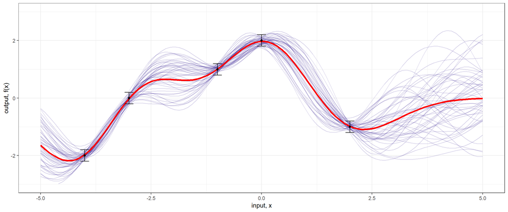

```r
options(warn=-1)
# 3. Now assume that each of the observed data points have some
# normally-distributed noise.

# The standard deviation of the noise
sigma.n <- 0.1

# Recalculate the mean and covariance functions
f.bar.star <- k.xsx%*%solve(k.xx + sigma.n^2*diag(1, ncol(k.xx)))%*%f$y
cov.f.star <- k.xsxs - k.xsx%*%solve(k.xx + sigma.n^2*diag(1, ncol(k.xx)))%*%k.xxs

# Recalculate the sample functions
values <- matrix(rep(0, length(x.star)*n.samples), ncol=n.samples)
for (i in 1:n.samples) {
  values[,i] <- mvrnorm(1, f.bar.star, cov.f.star)
}
values <- cbind(x=x.star,as.data.frame(values))
values2 <- melt(values, id="x")

# Plot the result, including error bars on the observed points
gg <- ggplot(values2, aes(x=x, y=value)) +
  geom_line(aes(group=variable), colour= rgb(0.1,0,0.5,0.2)) +
  geom_line(data=values, aes(x=x.star,y=f.bar.star),colour="red", linewidth=1.4) +
  geom_errorbar(data=f,aes(x=x,y=NULL,ymin=y-2*sigma.n, ymax=y+2*sigma.n), width=0.2) +
  geom_point(data=f,aes(x=x,y=y)) +
  theme_bw() +
  scale_y_continuous(lim=c(-3,3), name="output, f(x)") +
  xlab("input, x")
gg
```

Interesting links:

[Math of Gaussian regression](https://bookdown.org/rbg/surrogates/chap5.html)

[On the Matérn kernel](https://andrewcharlesjones.github.io/journal/matern-kernels.html)

[Some chunks of code](https://gist.github.com/sashagusev/c9287f488cd65c3ede9e)

[Medium article on kernels](https://towardsdatascience.com/gaussian-process-kernels-96bafb4dd63e)

[Exploring kernels](https://peterroelants.github.io/posts/gaussian-process-kernels/)

[Home Page](http://rinterested.github.io/statistics/index.html)

**NOTE: These are tentative notes on different topics for personal use - expect mistakes and misunderstandings.**